# IonStar USER MANUAL

For Build 0.1.4

## Introduction

[figure not shown]

IonStar is an MS1-based quantitative method for label-free proteomics experiments, devised to address issues related with quantitative precision, missing data, and false-positive discovery of protein changes in large-cohort analysis.

IonStar comprises of two parts: experimental procedures (left panel) and a proteomics data analysis pipeline (right panel). Details of the experimental procedures can be found in [Shen et al. *J Proteome Res.* (2017)](https://www.ncbi.nlm.nih.gov/pubmed/28412812) and [An et al. *Anal Chem.* (2015)](https://www.ncbi.nlm.nih.gov/pubmed/25746131).

This manual will focus on the data analysis pipeline part of IonStar, aiming at helping IonStar users to run the pipeline in their own computational environment.

## Prerequisites

### Software and dataset availability

The primary software packages used in IonStar are **SIEVE<sup>TM</sup>** and **IonStarStat**.

**SIEVE<sup>TM</sup>** is a commercial software from Thermo Fisher Scientific. The latest version of SIEVE<sup>TM</sup> is v2.2 SP2. Please contact Thermo Fisher Scientific regarding the quote for SIEVE<sup>TM</sup>. To ensure of proper performance of SIEVE<sup>TM</sup>, we recommend running SIEVE<sup>TM</sup> on a PC with at least 16-core processors and at least 192 GB RAM.

R package **IonStarStat** and related scripts (**IonStar_FrameGen.R**, **IonStar_Run.R**) can be downloaded [here](https://github.com/shichens1989/IonStarStat). All operations in this manual are accomplished under R version 3.4.3 and RStudio ver 1.1.442.

The dataset used in this manual as an example (Multi-level Human background+E.coli spike-in) can be downloaded from [PRIDE Archive](https://www.ebi.ac.uk/pride/archive) (PRIDE ID: PXD003881).

### Installing IonStarStat

IonStarStat package can be installed directly in RStudio by running the following commands in the R Console:

```r
#Install dependencies "RSQLite""MCMCglmm""affyPLM””mvoutlier”
source("https://bioconductor.org/biocLite.R")
biocLite("affyPLM")
biocLite("MCMCglmm")
biocLite("RSQLite")
install.packages("mvoutlier")
install.packages("IonStarStat_0.1.4.tar.gz", repos = NULL, type = "source")
```

Upon finishing installation, load IonStarStat into the R environment as follows:

```r
#Load IonStarStat
library("IonStarStat")
```

### File location

To perform using IonStar, it is recommended to put all files under the same working directory, including:

- LC-MS raw files `.raw`
- Spectrum report `.csv`, `.tsv`, or `.txt`
- SIEVE database file `.sdb`
- Annotated frame list `.csv`
- Sample list `.csv`
- Protein & peptide quantitative results `.csv`
- `IonStar_FrameGen.R` and `IonStar_Run.R`

Use `setwd()` to locate the files whenever necessary.

## Quickstart

[figure not shown]

### Step 1: Protein identification

Protein identification can be performed by any database searching engines and post-search processing tools. The final output is a so-called spectrum report containing PSMs from all sample runs passing the confidence threshold (*e.g.* FDR). The spectrum report can be exported from a number of software packages, *e.g.* **Proteome Discoverer**, **Scaffold**. Key information necessary for data integration include **rawfile name** and **MS2 scan number**. The file format of the spectrum report needs to be `.csv`.

The currently protein identification workflow used by our group features database searching by [MS-GF+](https://omics.pnl.gov/software/ms-gf), post-search processing by [IDPicker](http://proteowizard.sourceforge.net/idpicker/), and spectrum report generation by [IonStarSPG.R](https://github.com/shichens1989/IonStarStat). Detailed instructions can be found [here](https://github.com/shichens1989/IonStarStat).

### Step 2: Generation of quantitative features by SIEVE<sup>TM</sup>

Quantitative feature generation in IonStar is accomplished by SIEVE<sup>TM</sup> v2.2 SP2 (Thermo Scientific), which integrates ChromAlign for global 3-D chromatographic alignment and a direct ion current extraction (DICE) method for feature extraction.

#### 1. Load rawfiles into SIEVE<sup>TM</sup>

To start the quantitative feature generation analysis, open SIEVE<sup>TM</sup> and select **File -> Create new experiment**. On the **Designate Experiment Type** page, select the Experiment Type based on the study. For a case-control experiment, use **Two Sample Differential Analysis**; for multi-condition experiment (3 or more conditions including control), use **Control Compare Trend**.

[figure not shown]

Drag all rawfiles into the **Raw File Selection** page.

[figure not shown]

#### 2. Assign sample conditions and select reference file

For **Two Sample Differential Analysis**, assign *Condition A* and *Condition B* in the two boxes; For **Control Compare Trend**, put *all conditions* in the upper box and assign *the control condition* in the lower box.

Two Sample Differential Analysis:

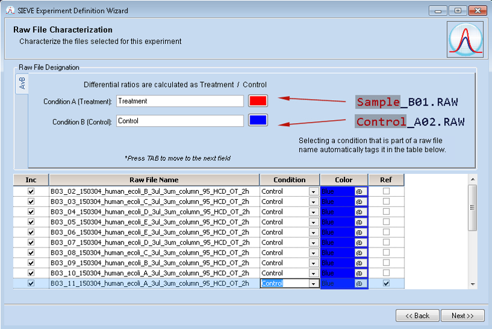

Control Compare Trend:

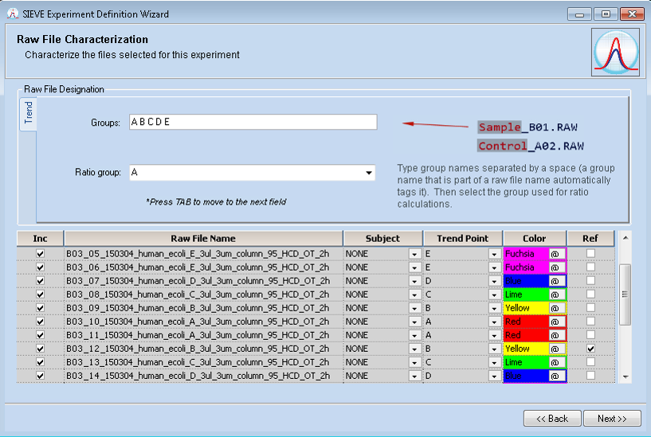

A reference file also needs to be selected. In general, the reference file should provide the highest alignment scores for all sample runs.In most cases, it is recommended to start with a file in the middle of the LC-MS sequence as the reference.

#### 3. Modify method parameters

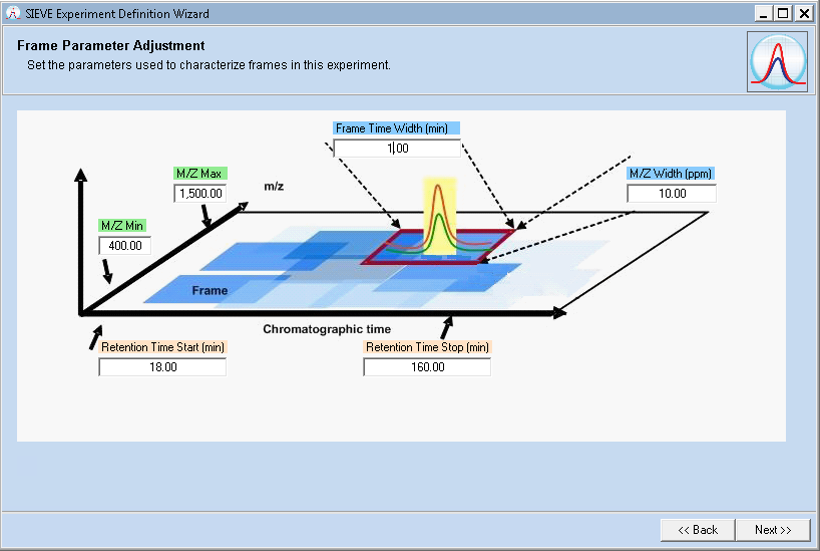

Check **Generate all frames based upon all MS2 scan’s retention times and precursor M/Zs** to maximize the number of quantitatve features. Alternatively, users can assign **Maximum Number of Frames** and **Peak Intensity Threshold**.

[figure not shown]

After setting the method, finish the wizard and save the `.sdb` file.

#### 4. Perform ChromAlign and DICE procedures

For IonStar, users do not need to run the **Identify** process. In the **SIEVE Parameters** window, **MaxThreads** should be changed according to the configuration of the computer used for SIEVE<sup>TM</sup>. For example, 6~8 threads are recommended for a PC with 16-core processors and 192 GB RAM. Occasionally, **PCAProcess** can also be disabled to alleviate computational burden. Click the **Update** button to save the settings. Run **Align** (ChromAlign) first.

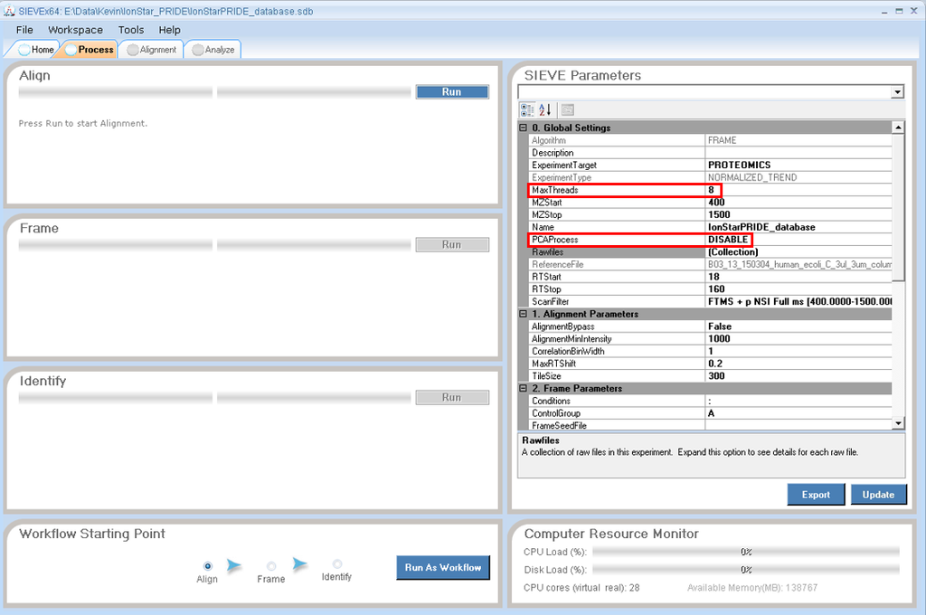

Upon finishing, alignment scores for all sample runs will be shown in the **Alignment** tab. Ideally, the majority of sample runs should have an alignment score of **>0.8** to ensure the quality of quantitative feature generation. Change the reference file and rerun the ChromAlign process if the alignment scores are subpar (*e.g.* <0.7) for a large portion of the files.

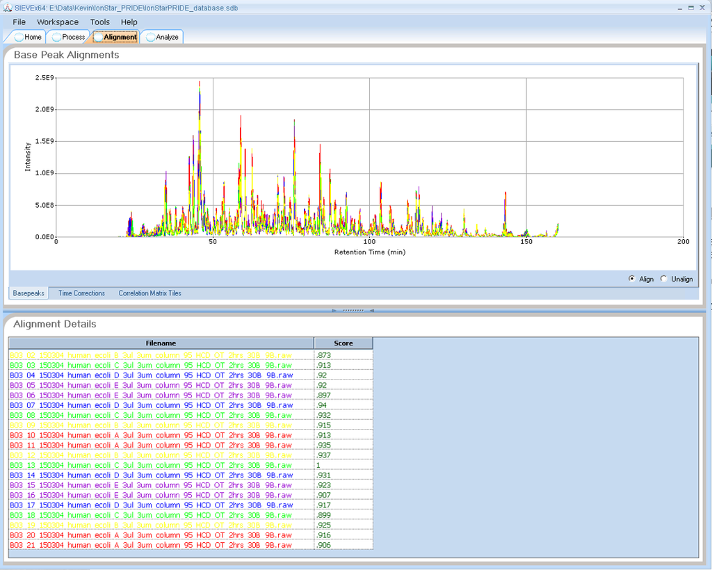

To change the reference file, click the **“…”** button in the **Rawfiles** line. Change the reference file by checking a new rawfile. Rerun **Align** and check the alignment scores again. When finished, run **Frame** to perform the DICE process.

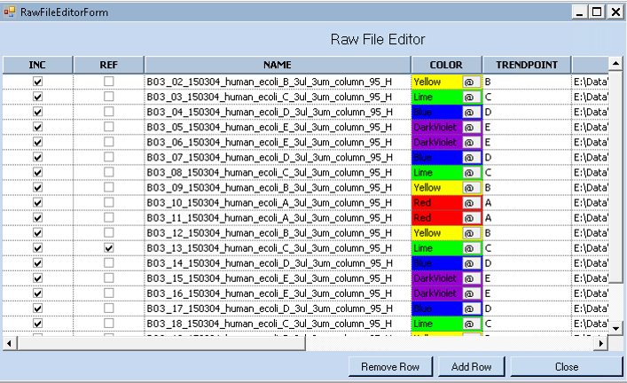

After feature generation, the `.sdb` file will contain all quantitative features (*i.e.* frames) generated. For more detailed information about the use of SIEVE, please refer to [SIEVE User Guide](https://tools.thermofisher.com/content/sfs/manuals/Man-XCALI-97696-SIEVE-22-User-ManXCALI97696-A-EN.pdf).

### Step 3: Data integration and quantification

After protein identification and quantitative feature generation, the R package **IonStarStat** will be utlized to integrate the spectrum report with the quantitative feature list and generate the final quantitative results. Procedures in this step include:

- Generation of the annotated frame list
- Removal of redundant quantitative features
- Frame-to-peptide aggregation & data normalization
- Multivariate mean variation-based outlier detection
- Shared peptide removal (optional)
- Peptide-to-protein aggregation

The codes for this step are enclosed in [IonStar_Run.R](https://github.com/shichens1989/IonStarStat).

#### 1. Generate the annotated frame list

In the spectrum report, the **rawfile name** column (`sp_col[1]`) should only contain the file name with no extension (*e.g.* II_B03_21_150304_human_ecoli_A_3ul_3um_column_95_HCD_OT_2hrs_30B_9B), and the **MS2 scan number** should be numeric (*e.g.* 58143).

Use the following codes to generate **the annotated frame list** and **the sample list**, which are both required for subsequent protein quantification. Make sure that the following packages are installed by running `install.packages(c("XLConnect","RSQLite"))`.

```r
##Generate the annotated frame list
db <- "IonStarPRIDE_database.sdb" ##File name of the SIEVE database
sp <- "IonStarPRIDE_spectrum report.csv" ##File name of the spectrum report
col_filename <- 4 ##Column number for rawfile name
col_scannum <- 17 ##Column number for MS2 scan number
col_framelist <- c(6,18) ##Column numbers for Protein accession number and Peptide sequence
framelist <- "IonStarPRIDE_frame.csv" ##File name of the annotated frame list (output1)
sampleid <-"IonStarPRIDE_sampleid.csv" ##File name of the sample list (output2)
source ("IonStar_FrameGen.R")
```

The annotated frame list `.csv` generated consists of **Protein accession number**, **Peptide sequence**, **Frame ID**, and **corresponding quantitative values in each sample**, shown as below.

```
##            ProteinAC             PepSeq FrameID        A1          B1
## 1 Q96I51:WBS16_HUMAN EAAEAEAEVPVVQYVGER   35199   5452494    475886.4
## 2  P0C8J6:GATY_ECOLI           INVATELK   11407 216541745 262224407.0
## 3  P0C8J6:GATY_ECOLI      NYLTEHPEATDPR    6302  50365797  52927424.6
## 4  P0C8J6:GATY_ECOLI QWVNLPLVLHGASGLSTK   47084  13635817  18975922.8
## 5  P0C8J6:GATY_ECOLI QWVNLPLVLHGASGLSTK   85743 158317760 128711136.1
## 6  P0C8J6:GATY_ECOLI  SVMIDASHLPFAQNISR   41490  47259460  47781835.2
##          C1        D1        E1        E2        D2        C2        B2
## 1   1391912   2289193   1302592   1146268   1645735   1091675   2789563
## 2 342242173 411246895 481214021 451974788 394233403 304898893 251107764
## 3  60233419  74382575  92162468  94188976  75480174  50618895  41996791
## 4  21041386  31074728  39476379  37953565  28216572  22198631  13746699
## 5 113131881 116859175 113338204 107014155 112368481 114584694 118152103
## 6  55798367  69234723  83597655  86098121  61897136  53934485  40421413
##            A2        A3        B3        C3        D3        E3        E4
## 1    660561.7   1583813   5148398   1923703   3842454   4221733   3554227
## 2 175357014.9 207088734 254629839 330040590 391575868 494867018 491473921
## 3  28891661.5  52817845  76774606  62542501 131993194 166741064 171442525
## 4   8390298.0  12464382  29358146  21184939  50791891  66393810  63215742
## 5 121447044.0 155394791 156556630 115749102 144621808 136891875 141464442
## 6  28736591.6  48176223  69299555  52708139 116873607 142661980 134440236
##          D4        C4        B4        A4
## 1   3582159   4278508   5723243   3780455
## 2 495393627 389784097 318133056 216134657
## 3 144341093 110284315  81203507  59372919
## 4  48868329  35728182  22188573  13603490
## 5 140116613 143775988 150280000 149897829
## 6 110236215  85939761  63125621  46183524
```

#### 2. Perform protein quantification

Before running the R codes, modify **the sample list** so that each sample is assigned a **GroupID**. **GroupID** can be any combinations of alphabetic and numeric symbols, *e.g.* *A*, *Group1*, *088714*.

```
##                                                               RawFiles
## 1  II_B03_21_150304_human_ecoli_A_3ul_3um_column_95_HCD_OT_2hrs_30B_9B
## 2  II_B03_02_150304_human_ecoli_B_3ul_3um_column_95_HCD_OT_2hrs_30B_9B
## 3  II_B03_03_150304_human_ecoli_C_3ul_3um_column_95_HCD_OT_2hrs_30B_9B
## 4  II_B03_04_150304_human_ecoli_D_3ul_3um_column_95_HCD_OT_2hrs_30B_9B
## 5  II_B03_05_150304_human_ecoli_E_3ul_3um_column_95_HCD_OT_2hrs_30B_9B
## 6  II_B03_06_150304_human_ecoli_E_3ul_3um_column_95_HCD_OT_2hrs_30B_9B
## 7  II_B03_07_150304_human_ecoli_D_3ul_3um_column_95_HCD_OT_2hrs_30B_9B
## 8  II_B03_08_150304_human_ecoli_C_3ul_3um_column_95_HCD_OT_2hrs_30B_9B
## 9  II_B03_09_150304_human_ecoli_B_3ul_3um_column_95_HCD_OT_2hrs_30B_9B
## 10 II_B03_10_150304_human_ecoli_A_3ul_3um_column_95_HCD_OT_2hrs_30B_9B
## 11 II_B03_11_150304_human_ecoli_A_3ul_3um_column_95_HCD_OT_2hrs_30B_9B
## 12 II_B03_12_150304_human_ecoli_B_3ul_3um_column_95_HCD_OT_2hrs_30B_9B
## 13 II_B03_13_150304_human_ecoli_C_3ul_3um_column_95_HCD_OT_2hrs_30B_9B
## 14 II_B03_14_150304_human_ecoli_D_3ul_3um_column_95_HCD_OT_2hrs_30B_9B
```

[output cut: 27 more lines]

Make sure to load `IonStarStat` by `library("IonStarstat")`. Read the annotated frame list and the grouped sample list into R environment.

```r
rawfile <- "IonStarPRIDE_Frame.csv"
condfile <- "IonStarPRIDE_Groups.csv"
raw <- read.csv(rawfile)
cond <- read.csv(condfile)
condition <- cond[match(colnames(raw)[-c(1:3)], cond[,1]),2]
condition
```

```
##  [1] A B C D E E D C B A A B C D E E D C B A
## Levels: A B C D E
```

Use `newProDataSet` to remove redundant frames (*i.e.* frames assigned to multiple peptide sequences), which causes ambiguity in quantification.

```r
pdata <- newProDataSet(proData=raw, condition=condition)
```

The number of proteins before and after removal, as well as the number of redundant frames removed will be reported in the console.

```
## Input 3886 proteins.
```

```
## 6489 duplicated frames founded.
```

```
## 3873 proteins left after filtering.
```

Use `pnormalize` to perform inter-sample normalization of quantitative intensities. Aggregation of frame data to peptide data can be done by `summarize=TRUE`. Normalization can be based on either total ion intensities (`method="TIC"`) or quantiles (`method="quantiles"`) in each sample. Use `method=NULL` to skip normalization.

```r
ndata <- pnormalize(pdata, summarize=TRUE, method="TIC")
```

Boxplots of peptide quantitative data before (left) and after (normalization) are shown as follows.

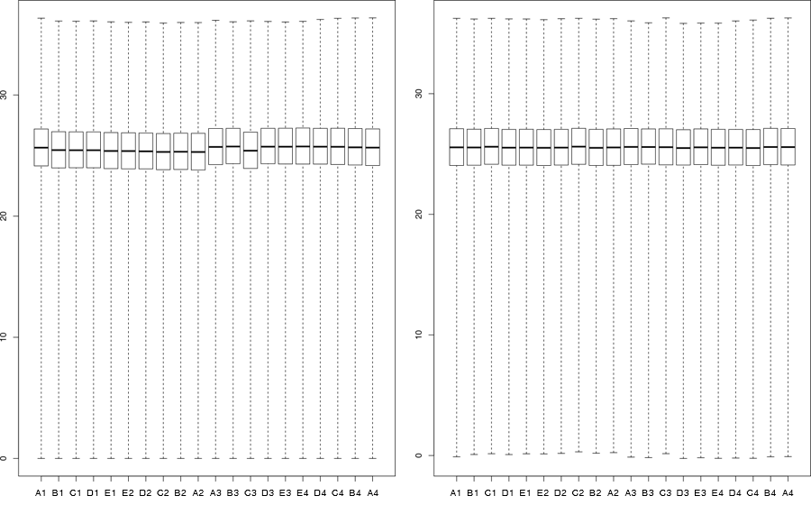

Use `OutlierPeptideRM` to perform outlier peptide detection. IonStar uses **Principal Component-based Outlier Detection (*PCOut*)** for outlier detection, which is tailored for multi-condition comparison (at least 3 conditions including control).

Parameter `variance` (0.7~0.9) can be adjusted according to the stringency needed for outlier detection. The higher the value the more outliers will be rejected.

```r
cdata<-OutlierPeptideRM(ndata,condition,variance=0.7,critM1=1/3,critM2=1/4,ratio=TRUE)
```

```
## 6049 outliers were removed; 21937 peptides left after outlier removal.
```

For **case-control comparison**, set parameter `ratio=FALSE`. Alternatively, **Grubb’s test** can be used for outlier rejection, which will be available in the next build of IonStarStat.

Use `SharedPeptideRM` to remove shared peptides (*i.e.* peptides inferred to multiple unique protein groups, *a.k.a.* degenerate peptides). This step is optional as many highly abundance proteins share a large proportion of homologous sequence domains. Removal of these peptides could be counterproductive for quantification. However, in specific cases, such as quantification of mixed-species samples, removal of shared peptides with species ambiguity is necessary to obtain species-specific quantitative results.

```r
#Opional removal of shared peptides
cdata<-SharedPeptideRM(cdata)
```

Use `ProteinQuan` to aggregate peptide-level quantitative data to protein level. Both sum intensities (`method="sum"`) and General Linear Mixed Model (`method="fit"`) can be used for peptide-to-protein aggregation.

```r
quan <- ProteinQuan(eset=cdata, method="sum")
```

```
##                    PepNum       A1       B1       C1       D1       E1
## A0AVT1:UBA6_HUMAN       4 26.62118 26.70643 26.70311 26.55632 26.56956
## A0FGR8:ESYT2_HUMAN     12 29.14639 29.14287 29.19418 29.11159 29.07409
## A0MZ66:SHOT1_HUMAN      8 27.38884 27.12556 27.21083 27.11330 27.08704
## A1L0T0:ILVBL_HUMAN      4 24.82774 25.34471 25.23324 25.22633 25.29648
## A1X283:SPD2B_HUMAN      4 25.91957 25.89851 25.98069 25.75741 25.62000
## A2RRP1:NBAS_HUMAN       2 23.21671 23.42673 23.27803 23.06164 22.72570
##                          E2       D2       C2       B2       A2       A3
## A0AVT1:UBA6_HUMAN  26.50505 26.59699 26.71673 26.65676 26.77142 26.80597
## A0FGR8:ESYT2_HUMAN 29.04383 29.11444 29.18659 29.18904 29.28187 29.19237
## A0MZ66:SHOT1_HUMAN 26.95478 27.11314 27.28457 27.07045 27.16919 27.32022
## A1L0T0:ILVBL_HUMAN 25.25879 25.39263 25.29545 25.22623 25.41492 25.25910
## A1X283:SPD2B_HUMAN 25.52778 25.70657 25.94787 25.87455 25.82754 26.14511
## A2RRP1:NBAS_HUMAN  22.98854 22.89805 23.27723 23.18188 23.39038 23.13157
##                          B3       C3       D3       E3       E4       D4
## A0AVT1:UBA6_HUMAN  26.63028 26.64539 26.37873 26.50122 26.37168 26.58727
## A0FGR8:ESYT2_HUMAN 29.11881 29.20611 28.87648 28.95956 28.84509 28.92555
## A0MZ66:SHOT1_HUMAN 27.35312 27.22668 27.28598 27.35093 27.21666 27.19223
## A1L0T0:ILVBL_HUMAN 24.90396 25.21406 24.71122 24.80994 24.84718 24.86370
## A1X283:SPD2B_HUMAN 25.99702 25.71892 25.62937 25.82062 25.72596 25.88044
## A2RRP1:NBAS_HUMAN  23.36878 23.10810 23.13342 22.86591 22.97998 23.19907
##                          C4       B4       A4
## A0AVT1:UBA6_HUMAN  26.50536 26.60836 26.72253
## A0FGR8:ESYT2_HUMAN 28.92343 29.11381 29.17440
## A0MZ66:SHOT1_HUMAN 27.25682 27.33590 27.39389
## A1L0T0:ILVBL_HUMAN 24.78118 24.96034 25.14340
## A1X283:SPD2B_HUMAN 25.80138 25.88904 26.01037
## A2RRP1:NBAS_HUMAN  22.89899 23.26405 23.07043
```

Users can export both peptide and protein quantitative results by `write.csv`.

```r
write.csv(quan,"IonStarPRIDE_protein_quan.csv")
write.csv(exprs(cdata),"IonStarPRIDE_peptide_quan.csv")
```

### Step 4: Post-quantification data processing

StarGazer, a Shiny-based interactive web app, will be made available in the next build of IonStar for post-quantification data processing. Fundamental functions of StarGazer include:

- Data cleanup and formatting
- Case-control protein ratio calculation
- Statistical testing
- Basic data mining (*e.g.* PCA, hierarchical clustering, fuzzy c-means clustering)
- Graphic depiction of quantitative data

## Contact information

For questions, suggestions, and other topics about IonStarStat, feel feel to contact us:

Shichen Shen: shichens@buffalo.edu

Xue Wang: xwang79@buffalo.edu

Jun Qu: junqu@buffalo.edu